# Pokročilé datové struktury a algoritmy

### ⓒ Jiří Fišer, MMXX, Přírodovědecká fakulta, UJEP, Ústí nad Labem

- Asymptotická složitost ([Jupyter](https://colab.research.google.com/github/JiriFiser/python-conda_pip/blob/master/nb1.ipynb))
- Časová složitost
- Paměťová složitost
- Benchmarking
- Obecné kolekce ([Jupyter](https://colab.research.google.com/github/JiriFiser/python-conda_pip/blob/master/nb2.ipynb))
- Lineární kolekce
- Speciální kolekce ([Jupyter](https://colab.research.google.com/github/JiriFiser/python-conda_pip/blob/master/nb3.ipynb))
- Orientované grafy
- Řídké matice
- Algoritmy rozděl a panuj ([Jupyter](https://colab.research.google.com/github/JiriFiser/python-conda_pip/blob/master/nb4.ipynb))
- Algoritmy sniž-a-panuj
- Efektivní řadící algoritmy
- Hladové algoritmy ([Jupyter](https://colab.research.google.com/github/JiriFiser/python-conda_pip/blob/master/nb5.ipynb))
- Algoritmy poskytující optimální řešení
- Další algoritmy využívající lokální rozhodování
- Algoritmy využívající náhodnost (pravděpodobnostní algoritmy) ([Jupyter](https://colab.research.google.com/github/JiriFiser/python-conda_pip/blob/master/nb6.ipynb))
- Hardwarové generátory náhodných čísel
- Transformace na posloupnost čísel
- Softwarové generátory pseudonáhodných čísel
- Generování náhodných hodnot z jiných rozdělení
- Randomizované verze standardních algoritmů

# 1. Asymptotická složitost

## Časová složitost

Při hodnocení algoritmů je klíčovým pojmem asymptotická časová složitost, který umožní klasifikovat algoritmy podle závislosti mezi velikostí úlohy a časem provedení.

Formální zavedení viz například: https://cw.fel.cvut.cz/b182/_media/courses/b6b36dsa/dsa-3-slozitostalgoritmu.pdf.

Přehled běžně se vyskytujích tříd nabízi anglická wikipedia (https://en.wikipedia.org/wiki/Time_complexity).

Pro praxi je třeba znát tato tvrzení a jejich důsledky:

1. řád růstu funkcí zohledňuje velké úlohy (velký počet zpracovávaných dat) a nemusí být relevantní pro malé úlohy (sofistikované algoritmy s "lepší" časovou složitostí mohou být na malých datech výrazně pomalejší než algoritmy triviální, například optimálním vyhledávacím algoritmem pro data s počtem položek v řádu jednotek je procházení seznamu a nikoliv hashovací tabulka).
2. *asymptotická složitost často závisí na vstupních datech*. Běžně se uvádí tzv. **typická složitost**, která je je dosažitelná s vysokou pravděpodobností pro náhodná vstupní data. Pro některé typy vstupních data však může být lepší (například třídění již uspořádaných dat algoritmem *insertion sort* má složitost $O(n)$ oproti typické $O(n^2)$), ale i horší (některé implementace algoritmu *quick sort*, který má typicky složitost $O(n\cdot log(n))$, třídí již setříděný seznam se složitostí $O(n^2)$)). Na rozdíl od notace používané v matematické teorie, se v praxi používá jen *big O* notace.
3. běžně sae předpokládá, že všechny elementární operace (porovnání, aritmetické operace, přesuny) mají konstantní časovou složitost (tj. využívají pro ukládání čísel či dalších objektů fixní paměťový prostor. To nemusí platit, pokud se využívá aritmetika s neomezenou přesností nebo řetězce s neomezenou délkou)

> Jaká je asympotická složitost následujících operací nad seznamem? (výmaz v tomto případě zahrnuje i posun všech následujících prvků o jednu pozici vlevo)
> 1. výmaz $n-k$ prvku kde $k$ je předem daná konstanta pro níž platí $\forall n, 0 \leq k < n$
> 2. výmaz $n/k$ prvku, kde výmaz $n-k$ prvku kde $k$ je předem daná konstanta pro níž platí $\forall n, 2 \leq k < n$

## Paměťová složitost

Paměťová složitost nehraje tak klíčovou roli. V praxi, lze rozeznávat následující případy:

1. algoritmus vyžaduje konstantní množství paměti bez ohledu na velikost
2. algoritmus nepotřebuje kromě vstupu žádnou dodatečnou paměť nebo jen (malou) konstantní či na logaritmu závislou paměť (většina třídících algoritmů, vyhledávání)
3. algoritmus potřebuje kopii původních dat resp. pomocnou strukturu s podobnou velikostí
4. algoritmus potřebuje ($k$-krát více paměti než vstup, kde $k$ je výrazně větší než 1)
5. algorimus využívá pomocnou paměť, jejíž velikost roste rychleji než lineárně

Algoritmy prvních tří skupin jsou aplikovatelné na počítačích, jejichž velikost (operační)paměti je nemusí být řádově větší než velikost vstupních dat. Do této skupiny spadá většina běžně používaných algoritmů a datových struktur.

Příkladem může být například *algoritmus* bucket sort, který má časovou složitost $O(n + \frac{n^2}{k} + k)$ a prostorovou $O(n\cdot k)$. Je-li $k$ velké, pak je časová složitost téměř lineární, ale pomocná data se již nemusí do paměti vejít.

## Benchmarking

Časovou složitost některých algoritmů lze relativně snadno odvodit (například u algoritmů, které procházejí jednoduché kolekce pomocí cyklů), u některých je to již složitější (některé typy rekurzivních algoritmů), a existují však algoritmy, u nichž lze složitost i za použití vyšší matematiky jen přibližně odhadnout.

Pro reálné nasazení je často nutné znát i přesnou závislost času vykonávání na velikosti úlohy. Tuto funkci lze ze zápisu algoritmu odvodit jen velmi přibližně na základě zjištění počtu jednotlivých operací. Reálnou rychlost implementace na konkrétní však silně ovlivňuje také:

- relativní rychlost jednotlivých operací (násobení je na některých platformách stejně rychlé jako sčítání, na jiných [bez harwarové násobičky]) je řádově pomalejší)
- interní paralelismus daný především šířkou zpracovávaných dat, zřetězeným zpracováváním operací (*pipelining*) a v některých případech i využitím SIMD vektorizace
- velikostí a charakterem jednotlivých úrovní mezipamětí (mezipaměť může výrazně ovlivnit efektiviru některých algoritmů)

Z tohoto důvodu má smysl využívat při implementaci a porovnání algoritmů benchmarking. Následující kód ukazuje implementuje jednoduchou funkci `benchmark`, která umožňuje testovat funkci resp. seznam funkcí pro různé hodnoty $n$ a několik dalších pomocných funkcí (funkce `plot` výsledek vizualizuje prostřednictvím, jednoduchého grafu).

> *Poznámka:* Obsah buňky s kódem je uložen do souboru `algbench.py` a může tak být importován jako modul.

```python
%%writefile algbench.py
import collections.abc
from time import perf_counter

def benchmark(algo_function, init, nrange, repetition=100):
    if not isinstance(algo_function, collections.abc.Iterable):
        algo_function = [algo_function]
    nlist = list(nrange)
    results = []
    for algo in algo_function:
        times = []

        for n in nlist:
            timesum = 0.0
            for _ in range(repetition):
                input = init(n)
                start = perf_counter()
                algo(input)
                end = perf_counter()
                timesum += end-start
            times.append(timesum/repetition)
        results.append(times)
    return (nlist, results)

def qplot(tdata, labels):
    import matplotlib.pyplot as plt
    for (times, label) in zip(tdata[1], labels):
        plt.plot(tdata[0], times, label=label)
    plt.xlabel("n")
    plt.ylabel("t(s)")
    plt.legend()
    plt.show()

def nrange(start, n = 10, step = None):
    step = step or start
    for i in range(start, start + n*step, step):
        yield i
```

```
Overwriting algbench.py
```

Pro otestování provedeme benchmark implementace standardní pythonské funkce `max` a tří implementací funkce `sum` (standardní pythonské přes iterátor a verze z knihovny `numpy` přes *numpy* n-dimenzionální pole, redukce operací plus přes iterátor) a také `numpy` implementace funkce `sort`

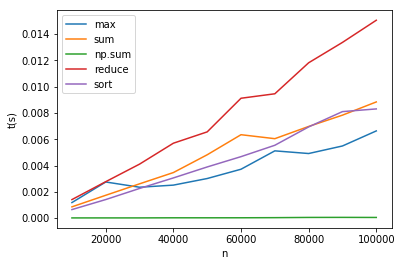

```python
from algbench import *
import numpy as np
from functools import reduce
import operator

r = benchmark(
    [max, sum, np.sum, lambda input: reduce(operator.add, input, 0.0), np.sort],
    lambda n: np.random.uniform(0.0,1.0,n), nrange(10000))

qplot(r, ["max", "sum", "np.sum", "reduce", "sort"])
```

Výsledek není překvapivý, neboť všechny implementace až na třídění používají triviální algoritmus, ve kterém se prochází všechny prvky pole a buď se sčítají, nebo se ukládá průběžné maximum (rychlejší algoritmus v tomto případě neexistuje). Časová složitost je tak lineární tj. $O(n)$ (i když směrnice u `numpy` verze je tak malá, že se na grafu jeví téměř jako konstantní). Třídící algoritmus se jeví jako by měl lineární složitost, to je však dáno volbou rozsahu velikostí polí (skutečbost je samozřejmě jiná viz úkol).

Mírně překvapit může velký rozdíl mezi numpy verzí (implementovanou v jazyce C) a verzemi vytvořenými přímo v Pythonu (z nichž nejhorší je ta využívající funkcionálního přístupu, Python není na rozdíl od jazyka Julia nakloněn funkcionálnímu programování). Pro pole velikostí desetitisíců položek je třídění pomocí `numpy` funkce stejně rychlé jako sumace či nalezení maximálního prvku). Těžko vysvětlitelná je i mírně rychlejší implementace vestavěné funkce `max` a oproti `sum` (v obou se v zásadě provádí n-krát operace plus resp. porovnání, které by měli být stejně rychlé).

> **Úkol**: Pomocí benchmarku ilustrujte, že třídění nemá lineární časovou složitost. Své pozorování ověřte prostřednictvím dokumentace k funkci `numpy.sort`.

Funkce `numpy.sort` používá algoritmus `quicksort`, který má typickou časovou složitost $O(n\cdot \log(n))$ (tu lze při použití pole s náhodným obsahem předpokládat s téměř absolutní jistotou). Pro zobrazení této závislosti je nutné, aby se výrazně měnil řád $n$.

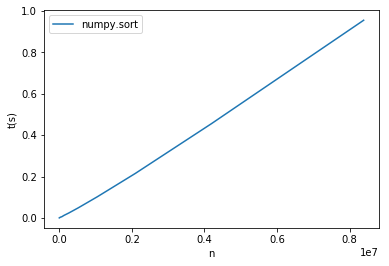

```python
from algbench import *
import numpy as np

r = benchmark(
    np.sort, # při použití jedné funkce lze seznam vynechat
    lambda n: np.random.uniform(0.0,1.0,n), (2**i for i in range(10,24)))

qplot(r, ["numpy.sort"])
```

# 2. Obecné kolekce

Obecné kolekce jsou datové struktury, které slouží k ukládání dat (tj. obecně objektů) a jsou využitelné v různých scénářích (tj. nikoliv jen pro určitý úzce definovaný účel). Obecné kolekce jsou často podporovány přímo běhovou podporou jazyka (aby byla jejich implementace rychlá a efektivní) resp. jsou naprogramovány prostřednictvím kódu v nízkoúrovňových jazycích (typicky je to jazyk C)

Obecné kolekce se mohou lišit:

- charakterem ukládaných hodnot
- rozhraním tj. nabídkou různých metod
- efektivitou jednotlivých operací (efektivita jednotlivých operací se může u jednotlivých kolekcí výrazně lišit)

Ve skutečnosti lze najít pouze jedinou operaci, která je sdílena všemi kolekcem, a tou je získání počtu položek (= uložených objektů).

## Lineární kolekce

Lineární kolekce uchovávají uspořádanou posloupnost objektů, tj. lze je procházet v určitém neměnném pořadí. Implementují tak uspořádané množiny (ordered set) známé z matematiky.

Většina druhů lineárních kolekcí podporuje efektivní získání i-té položky tzv. indexaci (tento druh lineárních kolekcí se v Pythonu označuje jako *sekvence*).

### Seznam

Základní lineární kolekcí jsou v Pythonu seznamy (*list*). Pokud seznamy neznáte, pak si si přečtěte stručný úvod do pythonských seznamů na http://diveintopython3.py.cz/native-datatypes.html (sekce 2.4).

Seznamy mají tuto charakteristiku:

- seznam obsahuje sekvenčně uložené odkazy na jednotlivé položky (nejsou uložené přímo v seznamu)
- indexace má konstantní časovou složitost
- do seznamu lze přidávat, ale efektivní je pouze přidávání na konec (časová složitost $O(1)$), přidávání na začátek nebo dovnitř seznamu má složitost $O(n)$
- prvky lze seznamu i odebírat (efektivní je opět jen odebírání na konci)

Python podporuje i neměnné sekvence, které se označují jako n-tice (*tuple*), ty jsou však užívány jen pro dočasné ukládání malého počtu prvků (maximálně malé desítky) a hrají tak v algoritmizaci jen pomocnou roli (nejčastěji se používají pro vracení více hodnot z funkcí).

### Oboustranná fronta

Standardní knihovna Pythonu však podporuje i jednu dodatečnou sekvenci: oboustrannou frontu (deque), což je de facto seznam, u něhož který podporuje rychlé přidávání na obou koncích seznamu.

Většina implementací oboustranné fronty umožňuje indexaci s konstantní složitostí (i když často pomalejší než u seznamů).

Popis rozhraní pythonské oboustranné fronty viz https://docs.python.org/3/library/collections.html#collections.deque

Existuje několik možných implementací oboustranných front, z nichž rychle indexovatelné jsou implementace založené na po částech souvislých seznamech, detaily viz https://en.wikipedia.org/wiki/Double-ended_queue.

> Úkol: pomocí benchmarkingu ověřte časovou charakteristiku oboustranné fronty (otestujte přidání na oba konce obou kolekcí)

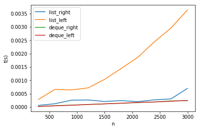

```python
import collections
from algbench import *

def list_append_right(n):
    c = []
    for i in range(n):
        c.append(i)

def list_append_left(n):
    c = []
    for i in range(n):
        c.insert(0, i)

def deque_append_right(n):
    c = collections.deque()
    for i in range(n):
        c.append(i)

def deque_append_left(n):
    c = collections.deque()
    for i in range(n):
        c.append(i)

r = benchmark([list_append_right, list_append_left, deque_append_right, deque_append_left],
              init= lambda n: n, nrange=nrange(300))
qplot(r, ["list_right", "list_left", "deque_right", "deque_left"])
```

### Pole (arrays)

Další velmi důležitou sekvencí je pole. Polem se povětšinou rozumí lineární datová struktura, jež je optimalizována na rychlý přístup položkám prostřednictvím pozičního indexu, nepodporuje však přidávání na konec (pojem pole a seznam však obecně splývají a v některých jazycích mohou být odlišeny i jinou charakteristikou).

Python pole přímo nepodporuje jsou však implementovány v knihovně NumPy.

Pole v NumPy maji tyto charakteristiky:

1) podporují vícedimenziální indexaci (tj. pole representuje matematické objekty označované jako tenzory) 2) podporují přímé ukládaní hodnot číselných typů v položkách pole (seznam i v případě elementárních typů využívá odkazy na číselné objekty) 3) jsou kompatibilní s poli v nízkoúrovňových jazycích (C nebo Fortran). Nejsou sice identické (nesou běhové metainformace), ale datová část je organizována stejně.

Rozdíl mezi paměťovou implementací mezi pythonským seznamem a Numpy polem ukazuje následující obrázek (převzatý z knihy *Python Data Science Handbook*).

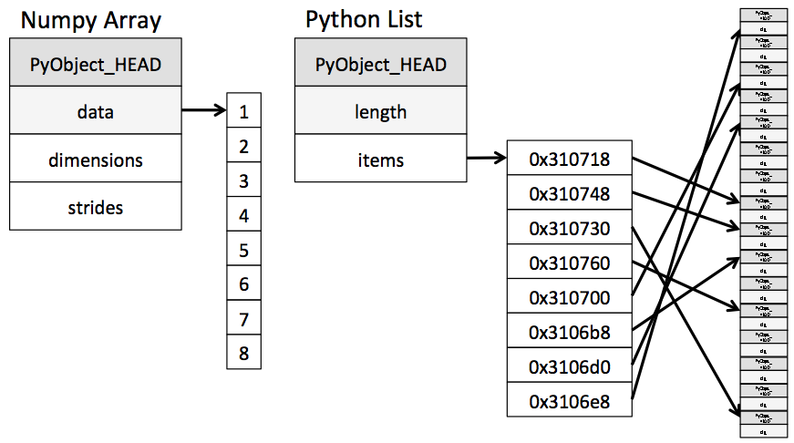

Pole jsou klíčovou datovou strukturou pro datovou vědu a i my je budeme často využívat. Přehledný popis numpy polí najdete například na stránkách *naucse,python.cz* (https://naucse.python.cz/lessons/intro/numpy/). Prostudujte také originální dokumentaci na stránkách https://numpy.org.

Zaměřit byste se měli především na funkce vytvářející pole (včetně polí vyplněná náhodnými hodnotami], indexaci včetně výřezů (*slice*), a skládání polí pomocí funkcí `vstack` nebo `hstack` resp. pomocí `r_` a `c_` indexace (je to tak trochu zneužití syntaxe indexace, ale je to užitečné).

> *Úkol*:

> Vytvořete následující pole (bez použití cyklů):
> 1. jednorozměrné pole 100 prvků typu int8 naplněné nulami
> 2. stejné pole ale naplněné čísly 0 až 99 (uložte je do proměnné `v`)
> 3. stejné pole ale naplněné číslem 255
> 4. stejné pole vyplněné náhodnými čísly v rozsahu 0 ... 255 s rovnoměrným rozdělením pravděpodobnosti
> 5. jednorozměrné pole typu float naplněné čísly přesně padesáti ekvidistaními čísly od 100 do 200 (včetně)
> 6. matici (= dvojrozměrné pole) položek typu double (float64) rozměru 5×5 bez vyplnění
> 7. stejnou matici, ale vyplněné náhodnýmí čísly s normálním rozdělením se střední hodnotou 100. a rozptylem 100
> 8. jednotkovou matici float64 čísel s rozměrem 100×100
> 9. trojrozměrné pole 3×10×10 s jehož první vrstva je tvořena čísly 1.0, druhá 2.0 a třetí 3.0
> 10. dvojrozměrné pole rozměrů 5×5, které je od levého horního rohu vyplněno po řádcích hodnotami 0.0 až 24.0 (uložte je do proměnné `m`)

```python
import numpy as np

v =np.arange(0,100, dtype=np.int8)
m = np.arange(0.0, 25.0).reshape(5,5)

print(v)
print(m)
```

```
[ 0  1  2  3  4  5  6  7  8  9 10 11 12 13 14 15 16 17 18 19 20 21 22 23
 24 25 26 27 28 29 30 31 32 33 34 35 36 37 38 39 40 41 42 43 44 45 46 47
 48 49 50 51 52 53 54 55 56 57 58 59 60 61 62 63 64 65 66 67 68 69 70 71
 72 73 74 75 76 77 78 79 80 81 82 83 84 85 86 87 88 89 90 91 92 93 94 95
 96 97 98 99]
[[ 0.  1.  2.  3.  4.]
 [ 5.  6.  7.  8.  9.]
 [10. 11. 12. 13. 14.]
 [15. 16. 17. 18. 19.]
 [20. 21. 22. 23. 24.]]
```

> *Úkoly*:
> 1. z jednorozměrného vektoru `v` (viz předchozí úkol) vytvořete výřez obsahující všechny prvky kromě prvního.
> 2. z vektoru `v` vytvořete výřez obsahující pouze prvky se sudým indexem (počítáno od nuly)
> 3. z vektoru `v` vytvořte výřez obsahující jen položky s lichými čísly (řešení musí fungovat pro pole s libovolným celočíselným obsahem)
> 4. z matice 'm' indexujte první dva řádky
> 5. z matice 'm' indexujte poslední dva sloupce
> 6. z matice indexujte podmatici tvořenou druhým a třetím řádkem a dtuhým až čtvrtým sloupcem

> Otázky:
> 1. V čem se liší paměťová representace výsledku úkolu 2 a 3?
> 2. V čem se liší zápis `m[1:2, 2:3] od zápisu`m[1,2]`?

### Spojový seznam

I přes bohatou nabídku kolekci v Pythonu v Pythonu a jeho standardních knihovnách, jedna z klasických lienárních kolekcí chybí: spojový seznam.

Spojový seznam (*linked list*) je tvořen jednoduchými datovými strukturami nazývanými uzly, které nesou hodnoty jednotlivých položek (tj. přímo jednotlivé položky nebo odkazy na ně) a vzájemně jsou spojeny sítí odkazů (refrencí). v případě jednosměrného seznamu je to vždy odkaz na následující uzel v v případě obosuměrného na předchozí.

Uzel, který nemá následovníka resp. předchůdce (u obousměrného seznamu) odkazuje na objekt `None`. Zvnějšku je vždy dostupný první prvek resp. prvek poslední (klíčové u obousměrného seznamu).

Mezi hlavní charakteristiky seznamu patří:

- konstantní čas přidávaní prvku kamkoliv do seznamu (je však nutno mít odkaz na prvek, za který resp. před který se prvek vkládá)
- neefektivní indexace (je nutno projít všechny prvky před hledaným, tj. časová složitost je průměrně $O(n)$).
- uzly nemusí ležet v paměti souvisle (což mimo jiné umožňuje flexibilnější úklid paměti)

Základní implementace jednosměrného seznamu je triviální, stačí nadefinovat třídu, jejiž instance jsou nové uzly.

```python
%%writefile linked_list.py

class Node:
    def __init__(self, val):
        self.value = val
        self.next = None # odkaz na počátku odkazuje na `None`

    def insertNodeAfter(self, nextnode):
        oldnext = self.next # uložíme si aktuální uzel
        self.next = nextnode # atribut `next` nyní odkazuje na vkládaný uzel
        nextnode.next = oldnext # a nastavíme odkaz na následující u vkládaného
        return nextnode

    def iter_to_end(self):
        node = self
        yield node.value
        while node.next is not None:
            node = node.next
            yield node.value
```

Použití implementovaného spojového seznamuje zřejmé.

```python
from linked_list import Node

start = Node(5)
start.insertNodeAfter(Node(6)).insertNodeAfter(Node(7))

start.insertNodeAfter(Node(5.5))

print(list(start.iter_to_end()))
```

> *Úkol*: Rozhraní třídy `Node` je bohužel trochu matoucí. Metoda `insertNodeAfter` vkládá jediný uzel (pokud je jí předán spojový seznam, pak vloží jen jeho první prvek a zbytek vkládaného seznamu zahodí). To odpovídá běžnému chápání abstraktního rozhraní může to však být matoucí. Například pro postupné řetězení nelze využít následující kód.

```python
chain = Node(5).insertNodeAfter(Node(6).insertNodeAfter(Node(7)))

print(list(chain.iter_to_end()))
```

> Implementujte metodu `insertChainAfter`, která umožní vkládat celé dílčí seznamy. Jaká je časová složitost této metody. Jakou časovou složitost má vytvoření seznamu o $n$ prvcích prostřednictvím vnitřního řetězení (tj. k prvnímu uzlu je připojen zbytek seznamu, který je opět vytvořen připojením zbytku seznamu k druhému uzlu, atd.

Časová složitost metody je $O(m)$, kde $m$ je délka přidávaného podseznamu (nezáleží na délce seznamu, do něhož se přidává, který je standardně označován jako $n$).

Časovou složitost vnitřního řetězení lze odvodit úvahou, že nejdříve se vytvoří poslední prvek, ten se přidá k předposlednímu (což si vyžádá traverzování přes jeden odkaz), výsledný dvouprvkový seznam se přidá k předpředposlednímu prvku (traverzování přes dva odkazy) a nakonec se seznam o dělce $n-1$ prvků přidá za první (s $n-1$ traverzováním). Celkový počet traverzovaní (každé vyžaduje porovnání a přiřazení) je tedy $1 + 2 + \cdots + (n-1) = \sum_{i=1}^{n-1} i$, což je součet jednoduché arimetické posloupnosti tj. $\frac{(n-1)\cdot n}{2}$. Časová složitost je tedy řádu $O(n^2)$, je tedy podstatně horší než vnější řetězení uvedené výše (to vkládá prvky od prvního do posledního) se složitosti $O(n)$. Cesta do pekel je dlážděna dobrými úmysly.

### Datové struktury optimalizované pro vyhledávání

Datové struktury optimalizované pro vyhledávání typicky ukládají dvojice objektů označovaných jako klíč a hodnota, přičemž nabízejí rychlou implementaci operace vyhledávání podle klíče (s asymtotickou časovou složitostí lepší než lineární). Rychlé by měly být i operace vkládání i výmazu (především pokud se předpokládá, že bude docházet k časté aktualizaci datové struktury).

#### Hashovací tabulky

Hashovací tabulky jsou nejčastěji používanými vyhledávacími datovými strukturami, které typicky dosahují ve všech třech základních operacích (vložení, vyhledávání, výmaz typické asymptotické složitosti $O(1)$, tj. čas prakticky nezávisí na velikosti kolekce.

Toto chování je však dosaženo jen při splnění následujících podmínek:

- existuje hashovací funkce, která libovolný vložený klíč zobrazí na celé číslo v rozsahu $0\cdots m$, tak že zajistí prosté zobrazení do množiny (tj. každý vstupní klíč zobrazí na jiné číslo) nebo minimalizuje počet kolizí (situací, kdy jsou dva či více klíčů zobrazeny na stejnou hodnotu). Průměrný počet kolidujících klíčů by neměl růst s velikostí kolekce (tj. počtem klíčů).
- je k dispozici dostatečné množství paměti, které závisí primárně na hodnotě $m$, ale i na $n$ (pokud je $n > m$)

  Hashovací tabulky můžete prostudovat na Wikipedii ([článek na anglické Wikipedii](https://en.wikipedia.org/wiki/Hash_table) je instruktivní a obsahuje přehled existujích přístupů), resp. (přímo pro Python, pak doporučuji [pythonds](https://runestone.academy/runestone/books/published/pythonds/SortSearch/Hashing.html).

Pozornost věnujte především problematice řešení kolizí (řetězení, otevřené násobení) a důvodům pro tzv. prehashování.

Hashovací tabulky jsou v Pythonu použity pro implementaci slovníků (`dict`) a množin (`set`, `frozenset`).

Implementace slovníků využívá otevřené adresování, kde se jako sondovací sekvence (*probing sequence*) používá jednoduchý generátor náhodných čísel. Velikost tabulky je mocninou dvou (počínaje osmi položkami) a tabulka je zdvojnásobena a rehashována pokud její zaplnění vzroste nad 2/3. Nověji se hashování provádí nad tabulkou indexů, které odkazují do lineární tabulky (viz [příspěvek na stackoverflow](https://stackoverflow.com/questions/327311/how-are-pythons-built-in-dictionaries-implemented)).

> **Otázka**: Proč je novější implementace slovníků (od verze 3.6) používá nepřímé adresování prostřednictvím seznamu indexů? Diskutujte především použití slovníků pro předávání pojmenovaných parametrů.

Python podporuje obecně i podporu hashovacích funkcí. Téměř všechny standardní třídy u nichž to dává smysl (instance jsou neměnné a lze testovat jejich shodu) jsou v Pythonu hashovatelné tj. implementují speciální metodu `__hash__`. Tato obecná metoda vrací číslo v rozmezí 0 až `maxint`. Reálně použitá hashovací funkce volá obecnou hashovací metodu, využívá však jen příslušný počet bitů (nižších) bytů.

Tyto obecné hashovací metody, mají relativně dobré chování pro náhodné vstupní hodnoty resp. hodnoty z běžně používaných podmnožin (např. hashování řetězcových hodnot má dobré chování i pro texty ve většině světových jazyků v běžných kódováních). Pro specializované skupiny řetězců však může být podíl kolozí větší.

V případě uživatelských tříd, u nichž se předpokládá, že busdou sloužit jako klíče, resp. budou ukládány do množiny je nutno definovat vlastní speciální metodu **hash**.

Tato metoda by měla splňovat tyto podmínky:

- výsledek by měl refletovat všechny dílčí hodnoty a jejich bity
- i malá změna dat (např. záměna jednoho písmene) by měla vést ke změně výsledné hodnoty
- hashované hodnoty by měli využívat všechny bity výsledku (výsledek je 64 bitový), pokud to není možné tak alespoň $n$-bitů, kde je $n$ dostatečně velké
- výpočet by měl být rychlý nejlépe s konstantní dobou provedení (nezávislou na rozsahu vtsupnách hodnot)

> **Úkol**: Diskutujte následující standardní implementaci metody `__hash__` (zkráceno a převedeno do Pythonu, originál je v jazyce C), vzhledem k výše uvedeným požadavkům.

> ```
> value = ord(self[0]) << 7
>         for char in self:
>             value = (1000003 * value) ^ ord(char) # násobení je omezeno na 64 bitů
>         value = value ^ len(self)
>         if value == -1:
>             value = -2
>         return value
> ```

Pro složené objekty se preferuje využití operace `xor` (zápis v Pythonu `^`) mezi všemi datovými členy, které se využívají v operaci testování shody. To je ve většíně případů dobrá volba (operace `xor` je rychlá zachovává rovoměrné rozložení bitů, nemusí však být vždy optimální, viz například následující úkol):

> **Úkol** Implementujte třídu pro representaci pozice šachové figurky využívající atributy `row` a `column`. Implementujte speciální metodu pro operátor rovnosti (`__eq__`) a obecnou hashovací metodu. Diskutujte metodu `__hash__` a pokuste se najít nejlepší řešení.

```python
class ChessPosition:
    def __init__(self, row, column):
        self.row = row
        self.column = column

    def __eq__(self, other):
        return self.row == other.row and self.column == other.column

    def __hash__(self):
        return hash(self.row) ^ hash(self.column)

p1 = ChessPosition(1,1)
p2 = ChessPosition(2,2)

print(hash(p1))
print(hash(p2))
```

```
0
0
```

Hashovací funkce využívající standardní přístup vrací pro všechny pole na diagonále (operace `xor` aplikovaná na dvě shodné hodnoty vrací vždy nulu). Jinak řečeno 1/8 možných instancé této třídy vrací stejnou hashovací hodnotu.

O něco lepším řešením by byla hashovací hodnota `row*8 + column`, která však v nižších bytech zohledňuje jen sloupec a nikoliv řádek (tj. při velikosti hashovací tabulky například 8 bytů rozhoduje spadají všechny pole nav jedmom sloupci do stejného místa tabulky, což však není překvapivé).

#### Binární vyhledávací stromy

Binární vyhledávací stromy (*binary search tree*) jsou klasickou datovou strukturou, která je založena na jednoduchém a elegantním přístupu. V typickém případě mají základní oprace nad binárními stromy časovou složitost $O(log(n))$, což je sice horší než v případe hashovacích tabulek, pro běžné velikosti kolekcí (= kolekcí, které se vejdou do paměti) však nejsou rozdíly velké.

Binární vyhledávací stromy lze aplikovat pouze pro položky, pro něž je definováno rozumné uspořádání tj. kromě relace rovnosti a nerovnosti musí být definovány i operace `<`, `<=`, `>` a `>=`, tak aby mezi nimi platily základní vztahy a uspořádání definované relací `<=` byli tzv. úplné (viz https://en.wikipedia.org/wiki/Total_order).

Kompletní a dobře zdokumentovanou implementaci binárních stromů najdete na stránkách *runestone.academy* (https://runestone.academy/runestone/books/published/pythonds/Trees/BinarySearchTrees.html).

Následující kód je převzat z výše uvedené implementace, je mírně upraven a okomentován:

```python
%%writefile binarysearchtree.py

import collections.abc

class TreeNode: # pomocná třídy: uzel binárního stromu
    def __init__(self,key,val,left=None,right=None,parent=None):
        self.key = key
        self.payload = val
        self.leftChild = left
        self.rightChild = right
        self.parent = parent

    def hasLeftChild(self):
        return self.leftChild is not None

    def hasRightChild(self):
        return self.rightChild is not None

    def isLeftChild(self):
        return self.parent and self.parent.leftChild == self

    def isRightChild(self):
        return self.parent and self.parent.rightChild == self

    def isRoot(self):
        return not self.parent

    def isLeaf(self):
        return not (self.rightChild or self.leftChild)

    def hasAnyChildren(self):
        return self.rightChild or self.leftChild

    def hasBothChildren(self):
        return self.rightChild and self.leftChild

    def spliceOut(self): # pomocná metoda pro výmaz
        if self.isLeaf():
            if self.isLeftChild():
                self.parent.leftChild = None
            else:
                self.parent.rightChild = None
        elif self.hasAnyChildren():
            if self.hasLeftChild():
                if self.isLeftChild():
                    self.parent.leftChild = self.leftChild
                else:
                    self.parent.rightChild = self.leftChild
                self.leftChild.parent = self.parent
            else:
                if self.isLeftChild():
                    self.parent.leftChild = self.rightChild
                else:
                    self.parent.rightChild = self.rightChild
                self.rightChild.parent = self.parent

    def findSuccessor(self): # pomocná metoda pro výmaz
        succ = None
        if self.hasRightChild():
            succ = self.rightChild.findMin()
        else:
            if self.parent:
                   if self.isLeftChild():
                       succ = self.parent
                   else:
                       self.parent.rightChild = None
                       succ = self.parent.findSuccessor()
                       self.parent.rightChild = self
        return succ

    def findMin(self): # pomocná metoda pro výmaz
        current = self
        while current.hasLeftChild():
            current = current.leftChild
        return current

    def replaceNodeData(self,key,value,lc,rc): # # pomocná metoda pro výmaz
        self.key = key
        self.payload = value
        self.leftChild = lc
        self.rightChild = rc
        if self.hasLeftChild():
            self.leftChild.parent = self
        if self.hasRightChild():
            self.rightChild.parent = self

    def __iter__(self): # iterátor přes (seřazené) klíče podstromu
       if self:
          if self.hasLeftChild():
                 for elem in self.leftChild:
                    yield elem
          yield self.key
          if self.hasRightChild():
                 for elem in self.rightChild:
                    yield elem


class BinarySearchTree(collections.abc.MutableMapping):
    def __init__(self):
        self.root = None
        self.size = 0

    def length(self):
        return self.size

    def __len__(self):
        return self.size

    def __iter__(self):
        return self.root.__iter__()

    def put(self,key,val):
        if self.root:
            self._put(key,val,self.root)
        else:
            self.root = TreeNode(key,val)
        self.size = self.size + 1

    def _put(self,key,val,currentNode):
        if key < currentNode.key:
            if currentNode.hasLeftChild():
                   self._put(key,val,currentNode.leftChild)
            else:
                   currentNode.leftChild = TreeNode(key,val,parent=currentNode)
        else:
            if currentNode.hasRightChild():
                   self._put(key,val,currentNode.rightChild)
            else:
                   currentNode.rightChild = TreeNode(key,val,parent=currentNode)

    def __setitem__(self,k,v):
       self.put(k,v)

    def get(self, key, default):
       if self.root:
           res = self._get(key,self.root)
           if res:
                  return res.payload
           else:
                  return default
       else:
           return default

    def _get(self,key,currentNode):
       if not currentNode:
           return None
       elif currentNode.key == key:
           return currentNode
       elif key < currentNode.key:
           return self._get(key,currentNode.leftChild)
       else:
           return self._get(key,currentNode.rightChild)

    def __getitem__(self,key):
       if self.root:
           res = self._get(key,self.root)
           if res:
                  return res.payload
           else:
                  raise KeyError("Invalid key")
       else:
           raise KeyError("Invalid key")

    def __contains__(self,key):
        if self._get(key,self.root):
           return True
        else:
           return False

    def delete(self,key):
      if self.size > 1:
         nodeToRemove = self._get(key,self.root)
         if nodeToRemove:
             self.remove(nodeToRemove)
             self.size = self.size-1
         else:
             raise KeyError('Error, key not in tree')
      elif self.size == 1 and self.root.key == key:
         self.root = None
         self.size = self.size - 1
      else:
         raise KeyError('Error, key not in tree')

    def __delitem__(self,key):
       self.delete(key)

    def remove(self,currentNode):
         if currentNode.isLeaf(): #leaf
           if currentNode == currentNode.parent.leftChild:
               currentNode.parent.leftChild = None
           else:
               currentNode.parent.rightChild = None
         elif currentNode.hasBothChildren(): #interior
           succ = currentNode.findSuccessor()
           succ.spliceOut()
           currentNode.key = succ.key
           currentNode.payload = succ.payload

         else: # this node has one child
           if currentNode.hasLeftChild():
             if currentNode.isLeftChild():
                 currentNode.leftChild.parent = currentNode.parent
                 currentNode.parent.leftChild = currentNode.leftChild
             elif currentNode.isRightChild():
                 currentNode.leftChild.parent = currentNode.parent
                 currentNode.parent.rightChild = currentNode.leftChild
             else:
                 currentNode.replaceNodeData(currentNode.leftChild.key,
                                    currentNode.leftChild.payload,
                                    currentNode.leftChild.leftChild,
                                    currentNode.leftChild.rightChild)
           else:
             if currentNode.isLeftChild():
                 currentNode.rightChild.parent = currentNode.parent
                 currentNode.parent.leftChild = currentNode.rightChild
             elif currentNode.isRightChild():
                 currentNode.rightChild.parent = currentNode.parent
                 currentNode.parent.rightChild = currentNode.rightChild
             else:
                 currentNode.replaceNodeData(currentNode.rightChild.key,
                                    currentNode.rightChild.payload,
                                    currentNode.rightChild.leftChild,
                                    currentNode.rightChild.rightChild)
```

```
Overwriting binarysearchtree.py
```

Výše uvedená implementace binárního stromu implementuje abstraktní datový typ `collections.abc.MutableMapping` (viz https://docs.python.org/3/library/collections.abc.html) a to prostřednictvím dědění (kromě přímo definovaných metod tak podporuje i zděděné tzv. *mixin* metody jako je metoda `keys`, `items`, `values`, i když ne příliš efektivně).

```python
from binarysearchtree import BinarySearchTree

tree = BinarySearchTree()
# vložení klíčů a hodnot
tree[2] = "dve"
tree[5] = "pet"
tree[4] = "ctyri"
tree[1] = "jedna"
tree[3] = "tri"

# nalezení hodnoty podle klíče
print(tree[2])

# iterace
for key in tree.keys():
    print(key)
```

```
dve
1
2
3
4
5
```

[output not shown]

> **Úkol**: Nakreslete tvar výsledného binárního stromu (stačí uvést pouze klíče).

> Rada: Zkuste použít nějaký vizualizátor binárních vyhledávacích stromů (např. http://btv.melezinek.cz/binary-search-tree.html)

Na rozdíl od minimalistické implementace spojového seznamu, implementuje výše uvedený kód obalovou třídu (tj. nikoliv jen stavební uzel). Kód je přehledný a samopopisný. Výjimkou je kód pro výmaz položky, který je dlouhý a navíc používá netriviální pomocné metody. Zde je detailnější prostudování implementace nezbytné.

Shrňme si základní charakteristiky jednoduchých binárních vyhledávacích stromů:

- typická časová složitost všech základních operací je $O(log(n))$, operace výmazu je však díky komplexnější implementaci méně efektivní (především u menších kolekcí).
- přes kolekci lze iterovat tak, že pro každý prvek platí, že je větší nebo rovný něž prvek předcházející (samozřejmě kromě prvního), tj. posloupnost je seřazená.

Triviální binární vyhledávací stromy však mají i problematické vlastnosti.

- rychlost všech operací závisí na hloubce stromu (= maximální vzdálenost od kořene k listu), pro kterou platí $h\geq \lfloor \log _{2}n\rfloor$. Pokud je stromu hloubka rovna minimální hodnotě (tj. $\lfloor \log _{2}n\rfloor$) pak se strom označuje jako **vyvážený**. Vyvážené stromy optimalizují rychlost všech základních operací.

V praxi dostačují i tzv. téměř vyvážené stromy, jejichž hloubka je rovna $k\cdot\lfloor \log _{2}n\rfloor$, kde $k \ll n$ (tj. je to dostatečně malé číslo, typicky menší než 3). Operace v téměř vyvážených stromech jsou pomalejší jejich asympotická časová složitost je však stále rovna $O(log(n))$.

Pokud jsou položk vkládány v náhodném pořadí, je strom téměř vždy téměř vyváženy. Pokud však čísla vkládáme již seřazená, pak vznikne absolutně nevyvážený strom s jednou dlouhou větví (bez větvení). Tento strom má hloubku $n$ (má jen jeden list) a jedná se de facto o spojový seznam, v němž mají všechny základní operace časovou složitost $O(n)$.

> **Úkol**: Implementujte funkci, která pro daný strom zjistí jeho hloubku. Ověřte, že hloubka stromu vzniklého z náhodné posloupnosti klíčů je téměř optimální.

```python
from binarysearchtree import BinarySearchTree, TreeNode
from numpy.random import rand

def tree_depth(tree: BinarySearchTree):
    return _depth(tree.root)

def _depth(node: TreeNode):
    if node is None:
        return 0
    return 1 + max(_depth(node.leftChild), _depth(node.rightChild))

def random_tree(n):
    tree = BinarySearchTree()
    for i,x in enumerate(rand(n)):
        tree[x] = i
    return tree

for _ in range(5):
    t = random_tree(2**20-1) # cca 1M prvků (optimální hloubka 20)
    print(tree_depth(t))
```

[output not shown]

Empirické výsledky ukazují, že se hloubka stromu pohybuje kolem 50, což je sice více než hloubka optimální (ta je 20), je to však stále o několik řádů méně než počet počet prvků.

> **Úkol**: Ověřte rychlost vytváření a vyhledávaní v binárních vyhledávacích stromech ve srovnání s hashovacími tabulkami pro různé řády hodnot n.

#### Samovyvažující se binární vyhledávací stromy

V případech, kdy nelze zaručit dostatečnou náhodnost vstupu (tj. například vstupní posloupnost obsahuje uspořádané podsekce), je nutné použít tzv. samovyvažujících se stromů. U těchto stromů dochází při vkládání k tzv. vyvažování tj. přeorganizování jednotlivých větví tak, aby byl strom téměř vyvážen (cílem není zcela optimální vyvážení).

##### Červenočerné stromy

Červenočerné stromy patří mezi nejoblíbenější samovyvažující se stromy, nabízejí rozumné vyvážení (maximální hloubka je dvojnásobek optimální) při relativně pochopitelné sémantice a algoritmech.

Detailní popis červenočerných stromů naleznete na stránkách https://algorithmtutor.com/Data-Structures/Tree/Red-Black-Trees/ a to včetně implementace.

> **Úkol**: Porovnejte výkonnost červenočerného a běžného binárního vyhledávacího stromu na náhodných datech resp. datech uspořádaných.

##### AVL stromy

Dalšími běžně používanými samovyvažujícími se stromy jsou AVL stromy. Detailní popis včetně implementace najdete na https://runestone.academy/runestone/books/published/pythonds/Trees/AVLTreeImplementation.html.

AVL stromy jsou de facto speciálním případem červenočerných stromů, dosahují však teoreticky lepšího vyvážení. Jejich hloubka je v nejhorším případě 0,72 krát lepší než je tomu u nejhoře vyvážených červenočerných stromů). Vyžadují však více uložených dat a implementace základních operací je o něco složitější.

# 3. Speciální kolekce

Speciální kolekce se v zásadě neliší od dříve uvedených kolekcí univerzálních, většinou však mají specifičtější rozhraní a neslouží tudíž primárně jako úložiště dat.

## Orientované grafy

Python ve své standardní podobě nepodporuje representaci orientovaných grafů resp. odvozených struktur (neorientovaných grafů, multigrafů, ohodnocených grafů apod.)

Jednotlivé typy grafů lze representovat mnoha způsoby například:

- maticí sousednosti
- řídkou maticí sousednosti
- seznamem hran
- slovníkem, jehož klíčem je označení uzlu a hodnotou seznam
- slovníkem, jehož klíčem je označení uzlu a hodnotou seznam sousedních vrcholů

Na stránce https://www.python-course.eu/graphs_python.php najdete detailní popis implementace třídy pro neorientované grafy.

> *Otázka*: Výše uvedená implementace je prezentována jako implementace neorientovaných grafů, ve skutečnosti je však vhodnější pro representace grafů orinetovaných. Uveďte proč?

Pro praktickou práci s grafy je však vhodnější využít komplexnějších knihovnu. Dporučuji knihovnu [NerworkX](https://networkx.github.io/). Prostudujte tutoriál knihovny: [NetworkX tutorial](https://networkx.github.io/documentation/stable/tutorial.html) a také první kapitolu knihy [NetworkX Reference](https://networkx.github.io/documentation/stable/_downloads/networkx_reference.pdf) resp. podle vašich zájmů i další části referenční příručky.

> **Otázka**: Knihovna používá pro representaci slovník slovníků (slovníků). Jaké výhody tato implementace přináší (paměťová a časová efektivita) a jaké jsou její nevýhody (omezení).

```python
!pip3 install networkx
```

[output not shown]

Řešení pomocí nízkoúrovňového přídávání hran (zdrojem je iterátor přes všechny dvojčlenné kombinace).

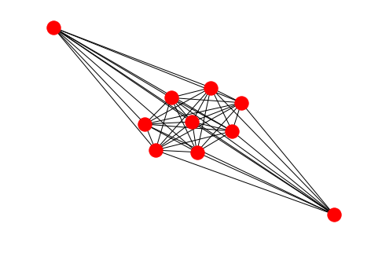

```python
import networkx as nx
import itertools
import matplotlib.pyplot as plt

g = nx.Graph()

for i in range(10):
    g.add_node(i)

g.add_edges_from(itertools.combinations(range(10),2))
nx.draw(g)
plt.show()
```

Řešení pomocí vestavěného generátoru.

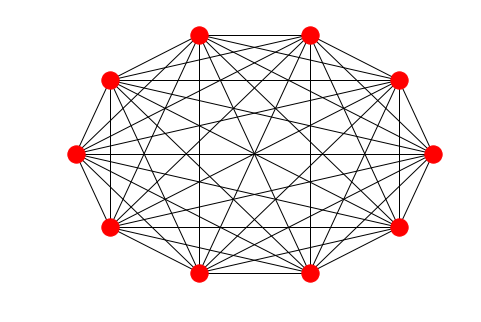

```python
g = nx.complete_graph(10)
nx.draw_shell(g)
plt.show()
```

> **Úkol**: Vytvořte neorientovaný ohodnocený graf, representující níže uvedenou tabulku dojezdových minimálních časů mezi krajskými městy (územních) krajů. Graf zobrazte.

> ```
>     BR        CB        HK        PR
> BR
> CB  02:21:00
> HK  02:14:00
> OS  01:42:00
> PR  01:58:00  01:40:00  01:16:00
> PL            02:00:00            01:02:00
> UL                                00:59:00
> ```

```python
d = nx.Graph()
d.add_edge("CB","BR", weight="2:21")
d.add_edge("HK","BR", weight="2:14")
d.add_edge("OS","BR", weight="1:42")
d.add_edge("PR","BR", weight="1:58")
d.add_edge("PR","CB", weight="1:40")

d.add_edge("PR","HK", weight="1:16")
d.add_edge("PL","CB", weight="2:00")
d.add_edge("PL","PR", weight="1:02")
d.add_edge("UL","PR", weight="0:59")

for f,t,w in d.edges(data="weight"):
    h,m = w.split(":")
    d[f][t]["weight"] = int(h) * 60 + int(m)
```

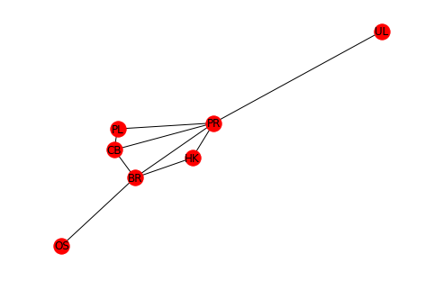

```python
nx.draw(d,  with_labels=True)
plt.show()
```

Vykreslování grafů je překvapivě komplexní problematika, kde nasazení běžných obecných algoritmů nevede k příliš kvalitním výsledkům. *NetworkX* využívá imlicitně tzv.pružinový algoritmus (viz [Force-directed graph drawing](https://en.wikipedia.org/wiki/Force-directed_graph_drawing)), jehož výsledky závisí na počáteční (náhodné) inicializaci. Je proto potřeba využít opakované vyhodnocení příslušného kódu. Stabilnější výsledky poskytuje algoritmus umisťující uzly do kruhů či soustředných kruhů (`draw_circular`, `draw_shell`), při tomto přístupu, však mohou vznikat i zbytečná křížení hran. Použít lze i zcela náhodné umisťování uzlů (`draw_random`).

## Fronty a zásobníky

Fronty a zásobníky jsou sekvenční kolekce s rozhraním, které je v zásadě omezeno jen na dvě operace: vkládání položky a její vyjímání. Běžně bývá podporováno i testování prázdnosti. Obě speciální kolekce se bežně implementují jako adaptéry nad obecnými sekvencemi (tj. interně využívají obecnější sekvence, navenek však poskytují jen obě výše uvedné metody resp. vlastnost).

Oba klasické abstraktní datové typy se liší sémantikou operace vyjímání. V případě zásobníků je vyjmuta poslední vložená (a nevyjmutá) položka v případě fronty je vyjmuta položka nejdřívě vložená (a samozřejmě ještě nevyjmutá).

Základní anglickou terminologii spojenou s frontami a zásobníky ukazuje následující tabulka:

[output not shown]

Zásobníky jsou v Pythonu snadno implementovatelné pomocí běžného seznamu a operací `append` a `pop` (s časovou složitostí $O(1)$). Pro testování prázdnosti lze využít běžný boolovský test (seznam je "pravdivý" tehdy pokud je neprázdný).

> **Úkol**: Naimplementujte adaptér nad seznamem. který bude podporovat jen základní operace zásobníku (testování prázdnosti pomocí speciální metody `__bool__`).

```python
class Stack:
    def __init__(self):
        self.data = []
    def __bool__(self):
        return bool(self.data)
    def push(self, item):
        self.data.append(item)
    def pop(self):
        return self.data.pop()

# test
s = Stack()
for i in range(5):
    s.push(i)

while(s): # dokud je neprázdný
    print(s.pop())
```

```
4
3
2
1
0
```

Čísla se vypisují v opačném gardu (první je vyjmuto a vypsáno poslední vložené).

Frontu lze teoreticky také implementovat pomocí seznamu, jen je nutné prvky vkládat na začátek seznamu. To je však neefektivní, neboť časová složitost této implementace by byla $O(n)$, kde n v tomto případě označuje aktuální délku fronty (tj. pokud je průměrná či ještě l=pe maximální aktuální délka fronty relativně malá v řádu malých desítek, pak je tato implementace bez problémů použitelná).

Stejnou efektivitu s konstatní časovou složitostí však nabízí obostranná fronta, u níž se využije jen vkládání na začátek a vyjímání na konci.

> **Úkol**: Naimplementujte adaptér nad oboustrannou frontou, který bude podporovat jen základní operace fronty (a testování prázdnosti pomocí speciální metody `__bool__`).

```python
import collections

class Queue:
    def __init__(self):
        self.data = collections.deque()
    def __bool__(self):
        return bool(self.data)
    def enqueue(self, item):
        self.data.appendleft(item)
    def dequeue(self):
        return self.data.pop()

# test
s = Queue()
for i in range(5):
    s.enqueue(i)

while(s): # dokud je neprázdný
    print(s.dequeue())
```

```
0
1
2
3
4
```

Pythonská standardní knihovna obsahuje i modul `queue`, která podporuje synchronizované fronty použitelné pro vícevláknové programy (pro programy víceprocesorové existuje implementace synchronizačních front v modulu `multiprocessing`).

> **Úkol**: Prostudujte dokumentaci na adrese https://docs.python.org/3/library/queue.html.

Synchronizační fronty se od běžných front liší v následujících charakteristikách:

Kromě klasické (a nejužitečnější) fronty je implementována i tzv. `LifoQueue` (trochu podivné kontradiktorické jméno je zde využito i pro zásobník) a tzv. prioritní fronta `PriorityQueue`, což je speciální kolekce se sémantikou podobná frontě, ale s možností předbíhání (prioritní fronta není frontou podle běžné definice fronty!).

> **Poznámka**: Použití netradičních jmen jako je `LifoQueue` a alternativních jmen je v některých kontextech dosti běžné. Při použití je proto důležité znát sémantiku každé kolekce a jejích metod.

> **Úkol**: Využijte priorotní frontu pro representaci fronty budoucích událostí v kalendáři. Každá událost je dána počátečním časem a prioritou 0 … 5 (5 je nejvyšší). Jako první je vyjímána událost, která nastane nejdříve, pokud je více takovýchto událostí, pak ta s vyšší prioritou . Rada: pro ukládání využijte trojice, v níž posledním členem je popis události resp. vlastní třídu s vhodně definovaným uspořádáním prvků.

### Cyklické fronty (buffery)

Termínem **cyklické fronty** (*circullar buffer*) se označuje specifická implementace front. Cyklické fronty mají omezenou velikost, lze je však implementovat prostřednictvím polí (tj. souvislých sekvencí fixních velikostí)

> **Úkol**: Nastudujte cyklické fronty (viz například hezký popis a animací na [Wikipedii](https://en.wikipedia.org/wiki/Circular_buffer)) a implementujte je jako třídu v Pythonu.

Cyklické fronty poskytují rychlé operace, jejiž časová složitost je i v nejhorším případě konstantní (není zde žádná dodatečná režie pro realokaci, apod.), oproti oboustranným frontám však mohou vyžadovat více paměti (alokována je vždy maximální velikost bez ohledu na uaktuální počet prvků ve frontě).

## Řídké matice

Především pro strojové učení jsou klíčovými datovými strukturami tzv. struktury efektivně representující tzv. řídké matice či obecněji pole (*sparse matrix(array)*). Jako řídká matice (či obecněji řídká pole) se označují matice, u nichž napoloviční počet položek obsahuje nulovou hodnotu (obecněji jakoukoliv fixní hodnotu, i když tento typ řídkých matic se v praxi příliš nevyskytuje).

Řídké matice lze samozřejmě representovat pomocí běžných polí, je to však neefektivní.

```python
import numpy as np
from random import randrange

def random_sparse_matrix(shape, values):
    n = len(values)
    m = np.zeros(shape, dtype=values.dtype)
    while(n > 0):
        x,y = randrange(shape[0]), randrange(shape[1])
        if m[x,y] == 0:
            m[x,y] = values[n-1]
            n -= 1
    return m

print(random_sparse_matrix((10,10), np.arange(0,11)))
```

```
[[ 0  0  0  0  0  0  0  0  0  0]
 [ 0  0  0  0  0  0  0  6  0  0]
 [ 0  5  0  0  0  0  0  0  0  0]
 [ 0  0  0  0  0  0  0  9  0  0]
 [ 0  0  0  2  0  0  0  0  0  0]
 [ 0  0  0  0  0  8  7  0  0  0]
 [ 0  0  0  1  0  0  0  0  0  0]
 [ 0  0  0  0  0  0  0  0 10  0]
 [ 3  0  0  0  0  0  0  0  0  0]
 [ 0  0  0  0  0  4  0  0  0  0]]
```

Hustota této řídké matice je jen 10% (= obsahuje jen 10% nenulových prvků) jenak řečeno řídkost (*sparsity*) je 90%. Matice zaujímá v paměti 10×10x8 = 800 bytů v paměti (pro 64bitové systémy).

Jednotlivé representace řídkých matic jsou uvedeny na [Wikipedii](https://en.wikipedia.org/wiki/Sparse_matrix). Detailnější popis a především dokumentaci rozhraní naleznete na [Scipy](https://docs.scipy.org/doc/scipy/reference/sparse.html).

> **Otázka**: Jaké z podporovaných formátů jsou vhodné pro konstrukci matice a jaké pro klíčové operace jako je násobení matic či výpočet inverzní matice?

> **Úkol**: V praxi vyřešte soustavu rovnic zadanou pomocí řídké (avšak regulární) matice (bez konverze).

# 4. Algoritmy rozděl a panuj

Algoritmy typu *rozděl a panuj* (*divide-and-conquer*) tvoří důležitou třídu algoritmů, které pracují na principu rekurzivního dělení problémů na dva či více (jednodušších) podproblémů. Tyto podproblémy jsou v rámcu rekurze děleny na podproblémy druhé úrovně a to pokračuje tak dlouho dokud nezískáme podproblémy, které jsou dostatečně malé aby jejich řešení bylo triviální (např. u třídících algoritmů je triviálním problémem seřazení jednoprvkových nebo dvojprvkových sekvencí).

Přirozeným programátorským přístupem pro algoritmy tohoto druhu je rekurze. Rekurze však přináší dodatečné paměťové nároky a nemusí být dostatečně efektivní. Pro určitou třídu algoritmů ntohoto druhu však lze nalézt nerekurzivní řešení a to buď přímým přepisem (je u algoritmů s tzv. koncovou rekurzí, které však nejsou typickými algoritmy rozděl a panuj, neboť v každém kroku vznikne jen jedna podúloha, viz níže) resp. komplexnějším přístupem.

## Algoritmy sniž-a-panuj

Tyto algoritmy jsou založeny nalezení jediné podúlohy, která výrazně sníží její rozsah (typické je například půlení, kdy je podúloha má nejvýše poloviční rozsah). Klasickou úlohou je binární vyhledávání, které bylo známo již ve starověku.

### Binární vyhledávání

Popis i analýzu algoritmu najdete na https://runestone.academy/runestone/books/published/pythonds/SortSearch/TheBinarySearch.html.

> **Otázka**: Jaké jsou výhody a nevýhody tohoto algoritmu ve srovnání s využitím specializovaných vyhledávacích kolekcí jako je binární strom nebo hashovací tabulka?

Binírní vyhledávání je základem standardního modulu *bisect*, který kromě vyhledávání podporuje i vkládání (hledá i pozice vhodné pro vložení), dokumentace viz https://docs.python.org/3.8/library/bisect.html.

> **Úkol**: Implementujte binární pomocí rekurze i bez rekurze. Určete paměťovou složitost obou řešení a porovnejte jejich rychlost.

## Efektivní řadící algoritmy

Nejefektivnější univerzální řadící algoritmy jsou založeny na mechanismu rozděl a panuj. Jedná se především o algoritmy `quicksort` a `mergesort`.

Popis algoritmu quicksort včetně jeho implementace najdete na https://runestone.academy/runestone/books/published/pythonds/SortSearch/TheQuickSort.html. Tento článek nediskutuje volbu tzv. pivota, což může výrazně ovlivnit efektivitu pro některé vstupy. Dobrým východiskem této klíčové diskuse je článek na [wikipedii](https://en.wikipedia.org/wiki/Quicksort).

> **Úkol**: Diskutujte výhody a nevýhody volby pivota mediánem (ze tří) a náhodné volby mediánu (nejhorší časová složitost, reálná rychlost).

Algoritmus `mergesort`, je ve většině případů pomalejší než `quicksort`, ale je stabilní (tj. zachovává pořadí položek se stejným řadícím klíčem) a i v nejhorším případě má časovou složitost $O(n log(n)$

Implementace algoritmu `mergesort` v Pythonu (včetně diskuse) je uvedena např. v https://runestone.academy/runestone/books/published/pythonds/SortSearch/TheMergeSort.html (prostudujte).

> **Úkol**: Porovnejte rychlost obou třídících algoritmů (u `quicksort` s triviální volbou pivota a 3-mediánem ) pro pole s náhodným čísleným obsahem resp. již setříděná pole (včetně setříděných o opačné gardu). Interpretujte výsledky.

# 5. Hladové algoritmy

Jako hladové algoritmy se označují algoritmy, které hledají určité (globální) optimum tím, že provádějí lokální rozhodnutí na lokální úrovni.

Hladové algoritmy obecně nemusí najít optimální řešení a ve specifických případech mohou dokonce najít to nejhorší možné. Pro širokou třídu problémů však vedou k řešení, které je akceptovatelně blízké skutečnému a je tak využít jako heuristiky. Pro určité třídy problémů hladové algoritmy najdou vždy nejlepší řešení.

Třídě hladových algoritmů jsou blízké i algoritmy, jejichž cílem není optimalizace, ale prohledání určitého stavového prostoru či seřazení prvků založené na principu lokální volby.

Elementárním a v praxi často používaným algoritmem je algoritmus hledající nejmenší počet mincí či bankovek potřebných pro zaplacení určité sumy. V tomto algoritmu stačí v každém kroku zvolit vždy největší minci/bankovku menší než je zbývající suma (lokální rozhodnutí). Tento algoritmus nemusí obecně vést k optimálnímu rozhodnutí, v případě měnového systému v ČR (a mnoha dalších zemí) však vždy nalezne optimální řešení.

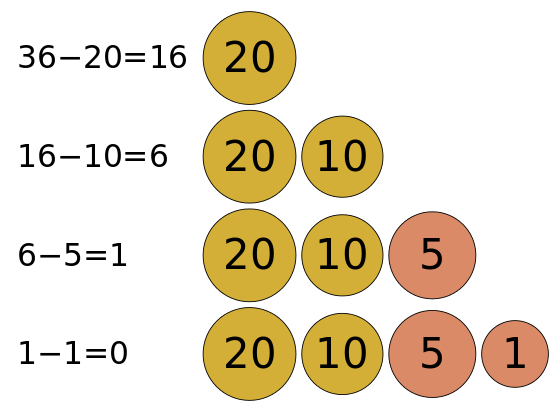

Obecné řešení vyžaduje využití dynamického programování viz například https://www.geeksforgeeks.org/find-minimum-number-of-coins-that-make-a-change/ nebo článek na [Wikipedii](https://en.wikipedia.org/wiki/Change-making_problem).

> **Poznámka**: Zjištění zda lze pro určité nominální hodnoty mincí bankovek najít optimální řešení pomocí hladového algoritmu je (tj. zda jde o tzv kanonický systém) není triviální, viz [Xuan Cai and Yiyuan Zheng, nonical Coin Systems for Change-Making problems](https://arxiv.org/PS_cache/arxiv/pdf/0809/0809.0400v1.pdf)